# Tugas Praktikum 4 - Proses ARMA(2)

Fitria Angelita Delvi

2026-09-23

# 1. Bangkitkan ARMA(2,2) Secara Manual

```r
set.seed(123)

n <- 300

phi1 <- 0.5
phi2 <- 0.2

theta1 <- 0.4
theta2 <- 0.6

e <- rnorm(n, mean = 0, sd = 1)

Y_manual <- numeric(n)

Y_manual[1] <- e[1]
Y_manual[2] <- e[2]

for (t in 3:n) {

  Y_manual[t] <-
    phi1 * Y_manual[t - 1] +
    phi2 * Y_manual[t - 2] +
    e[t] +
    theta1 * e[t - 1] +
    theta2 * e[t - 2]
}

head(Y_manual)
```

```
## [1] -0.5604756 -0.2301775  0.9031681  0.9614338  1.7540666  2.8784052
```

Berdasarkan hasil pembangkitan secara manual, diperoleh 300 data dari proses ARMA(2,2) dengan parameter $\phi_1=0,5$, $\phi_2=0,2$, $\theta_1=0,4$, dan $\theta_2=0,6$. Enam pengamatan pertama yang diperoleh berturut-turut adalah -0,5605; -0,2302; 0,9032; 0,9614; 1,7541; dan 2,8784. Data tersebut menunjukkan adanya fluktuasi nilai dari waktu ke waktu sebagai hasil pengaruh komponen autoregresif, moving average, dan error.

# 2. Bangkitkan ARMA(2,2) dengan arima.sin()

```r
set.seed(123)

Y_arima <- arima.sim(
  model = list(
    ar = c(0.5, 0.2),
    ma = c(0.4, 0.6)
  ),
  n = 300
)

head(Y_arima)
```

```
## Time Series:
## Start = 1
## End = 6
## Frequency = 1
## [1] -3.11187150 -2.78699743 -1.12528900 -0.87493596 -0.03472262  0.84062710
```

Berdasarkan hasil pembangkitan menggunakan fungsi arima.sim(), diperoleh 300 data dari proses ARMA(2,2) dengan parameter $\phi_1=0,5$, $\phi_2=0,2$, $\theta_1=0,4$, dan $\theta_2=0,6$. Enam pengamatan pertama yang dihasilkan adalah -3,1119; -2,7870; -1,1253; -0,8749; -0,0347; dan 0,8406. Nilai-nilai tersebut menunjukkan adanya perubahan dan fluktuasi dari satu periode ke periode berikutnya yang dihasilkan oleh kombinasi komponen autoregresif dan moving average.

#3. Plot Time Series

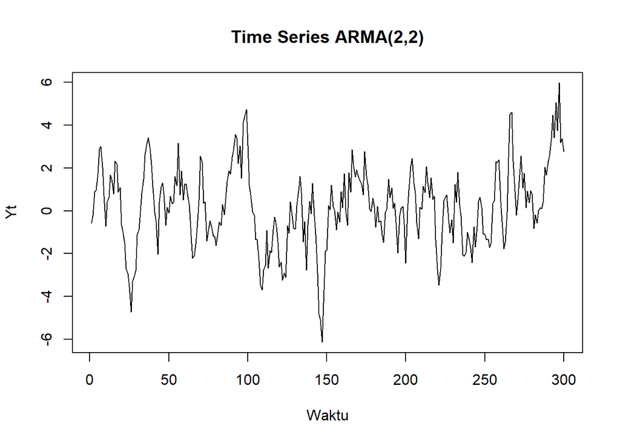

```r
plot(
  Y_manual,
  type = "l",
  main = "Time Series ARMA(2,2)",
  xlab = "Waktu",
  ylab = "Yt"
)
```

Berdasarkan plot time series ARMA(2,2), data menunjukkan pola yang berfluktuasi dari waktu ke waktu tanpa adanya tren naik atau tren turun yang sistematis. Meskipun terdapat beberapa pengamatan dengan nilai yang relatif tinggi maupun rendah, fluktuasi data secara umum berada di sekitar nilai tengah. Dengan demikian, berdasarkan plot time series, data cenderung stasioner, karena tidak terlihat adanya perubahan rata-rata yang sistematis sepanjang periode pengamatan dan penyebaran data secara umum relatif stabil.

# 4. Plot ACF

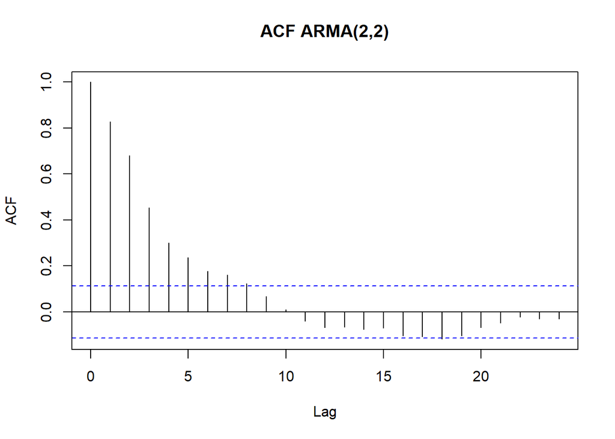

```r
acf(
  Y_manual,
  main = "ACF ARMA(2,2)"
)
```

Berdasarkan plot ACF ARMA(2,2), nilai autokorelasi pada lag 1 sangat tinggi dan bernilai positif. Selanjutnya, nilai ACF mengalami penurunan secara bertahap seiring bertambahnya lag. Beberapa lag awal masih menunjukkan autokorelasi yang signifikan, kemudian nilai ACF semakin mendekati nol. Pola penurunan secara bertahap tersebut menunjukkan karakteristik tailing off, yang sesuai dengan proses ARMA(2,2).

# 5. Plot PACF

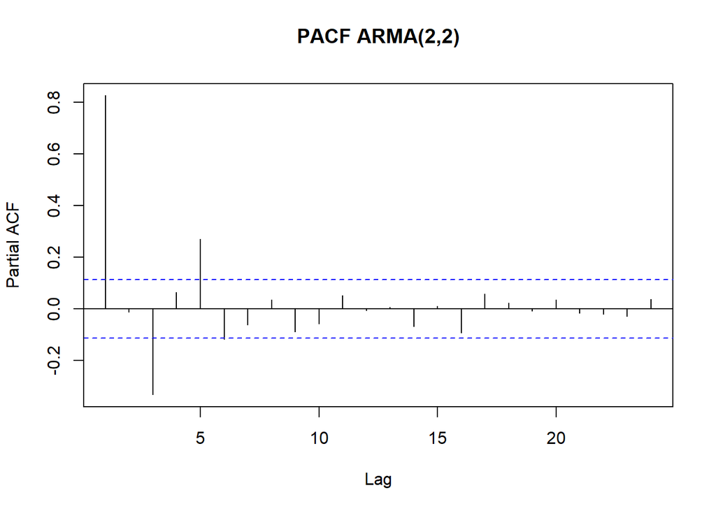

```r
pacf(
  Y_manual,
  main = "PACF ARMA(2,2)"
)
```

# 6. Plot EACF

```r
library(TSA)
```

```r
eacf(Y_manual)
```

```
## AR/MA
##   0 1 2 3 4 5 6 7 8 9 10 11 12 13
## 0 x x x x x x x x o o o  o  o  o
## 1 o x o x o o o o o o o  o  o  o
## 2 o x o x o o o o o o o  o  o  o
## 3 x x o x o o o x o o o  o  o  o
## 4 x x o x o o o x o o o  o  o  o
## 5 x x o x x o o o o o o  o  o  o
## 6 x x o x o o o o o o o  o  o  o
## 7 x o x x x o o o o o o  o  o  o
```

Berdasarkan hasil EACF, pada posisi $(p,q)=(2,2)$ diperoleh simbol o, yang menunjukkan bahwa model ARMA(2,2) termasuk salah satu kandidat yang didukung oleh pola EACF. Hasil ini sesuai dengan model yang digunakan dalam pembangkitan data, yaitu memiliki orde AR sebesar 2 dan orde MA sebesar 2. Meskipun terdapat beberapa kombinasi orde lain yang juga menunjukkan simbol o, identifikasi model perlu mempertimbangkan hasil ACF dan PACF serta struktur model yang digunakan.

# 7. Membuat Lag

```r
Y_t  <- Y_manual[4:300]
Y_t1 <- Y_manual[3:299]
Y_t2 <- Y_manual[2:298]
Y_t3 <- Y_manual[1:297]
```

# 8. Scatterplot Yt vs Yt-1

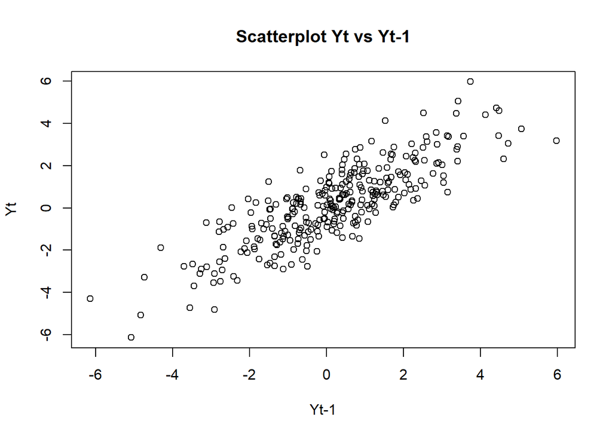

```r
plot(
  Y_t1,
  Y_t,
  main = "Scatterplot Yt vs Yt-1",
  xlab = "Yt-1",
  ylab = "Yt"
)
```

Berdasarkan scatterplot antara $Y_t$ dan $Y_{t-1}$, terlihat adanya hubungan linear positif. Hal ini ditunjukkan oleh titik-titik yang cenderung membentuk pola dari kiri bawah menuju kanan atas. Artinya, ketika nilai $Y_{t-1}$ meningkat, nilai $Y_t$ juga cenderung meningkat. Meskipun demikian, titik-titik tidak berada tepat pada satu garis sehingga hubungan tersebut tidak sempurna.

# 9. Scatterplot Yt vs Yt-2

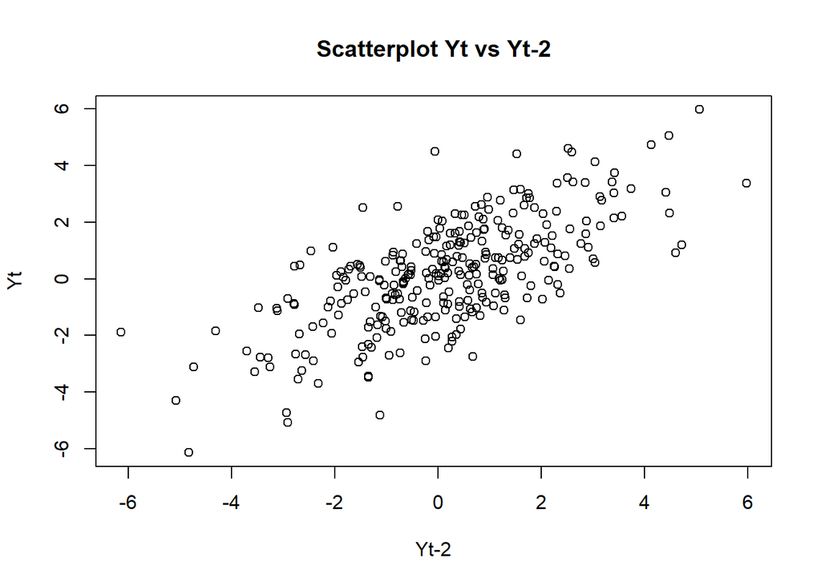

```r
plot(
  Y_t2,
  Y_t,
  main = "Scatterplot Yt vs Yt-2",
  xlab = "Yt-2",
  ylab = "Yt"
)
```

Berdasarkan scatterplot antara $Y_t$ dan $Y_{t-2}$, terlihat adanya kecenderungan hubungan linear positif. Titik-titik secara umum bergerak dari kiri bawah menuju kanan atas, sehingga peningkatan nilai $Y_{t-2}$ cenderung diikuti oleh peningkatan nilai $Y_t$. Namun, titik-titik pengamatan cukup menyebar sehingga hubungan antara kedua variabel tidak sempurna.

# 10. Scatterplot Yt vs Yt-3

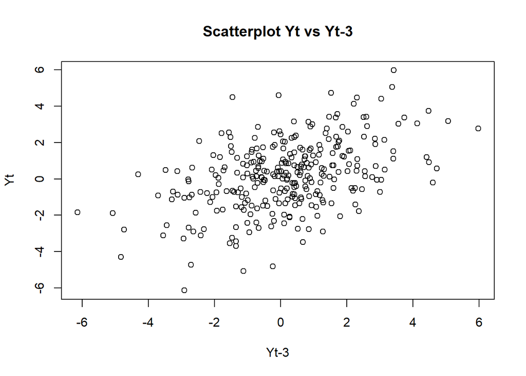

```r
plot(
  Y_t3,
  Y_t,
  main = "Scatterplot Yt vs Yt-3",
  xlab = "Yt-3",
  ylab = "Yt"
)
```

Berdasarkan scatterplot antara $Y_t$ dan $Y_{t-3}$, terlihat adanya kecenderungan hubungan linear positif, meskipun titik-titik pengamatan cukup menyebar. Secara umum, titik-titik menunjukkan pola dari kiri bawah menuju kanan atas. Hal ini menunjukkan bahwa ketika nilai $Y_{t-3}$ meningkat, nilai $Y_t$ cenderung meningkat, tetapi hubungan tersebut lebih lemah dibandingkan hubungan pada lag 1 dan lag 2.

# 11. ACF Data Bangkitan

```r
acf_result <- acf(
  Y_manual,
  plot = FALSE
)

data.frame(
  Lag = 1:3,
  ACF_Data = as.numeric(acf_result$acf[2:4])
)
```

[output not shown]

# 12. Autokorelasi Data Bangkitan

```r
length(Y_manual)
```

```
## [1] 300
```

```r
head(Y_manual)
```

```
## [1] -0.5604756 -0.2301775  0.9031681  0.9614338  1.7540666  2.8784052
```

```r
acf(Y_manual, plot = FALSE)$acf[2:4]
```

[output not shown]

```r
cor(Y_manual[2:300], Y_manual[1:299])
```

```
## [1] 0.8296986
```

```r
cor(Y_manual[3:300], Y_manual[1:298])
```

```
## [1] 0.685469
```

```r
cor(Y_manual[4:300], Y_manual[1:297])
```

```
## [1] 0.4591536
```

Berdasarkan perhitungan korelasi menggunakan fungsi cor(), diperoleh nilai autokorelasi sebesar 0,8297 pada lag 1, 0,6855 pada lag 2, dan 0,4592 pada lag 3. Seluruh nilai menunjukkan korelasi positif. Nilai tersebut juga mengalami penurunan dari lag 1 hingga lag 3, yang menunjukkan bahwa hubungan antara pengamatan saat ini dengan pengamatan pada periode sebelumnya semakin melemah ketika jarak lag bertambah.

# 13. Autokorelasi Teoritis

```r
acf_teori <- ARMAacf(
  ar = c(0.5, 0.2),
  ma = c(0.4, 0.6),
  lag.max = 3
)

acf_teori[2:4]
```

```
##         1         2         3
## 0.8591993 0.7491908 0.5464353
```

Berdasarkan hasil perhitungan ACF teoritis untuk proses ARMA(2,2), diperoleh nilai autokorelasi sebesar 0,8592 pada lag 1, 0,7492 pada lag 2, dan 0,5464 pada lag 3. Seluruh nilai autokorelasi bernilai positif dan mengalami penurunan seiring bertambahnya lag. Hal ini menunjukkan bahwa $Y_t$ memiliki hubungan positif dengan nilai-nilai pada periode sebelumnya, tetapi kekuatan hubungan tersebut semakin melemah ketika jarak waktu semakin jauh.

# 14. Tabel Perbandingan

```r
hasil_acf <- data.frame(
  Lag = 1:3,
  ACF_Data = as.numeric(acf_result$acf[2:4]),
  ACF_Teoritis = acf_teori[2:4]
)

hasil_acf
```

[output not shown]

# 15. Kesimpulan

Nilai ACF empiris lebih rendah daripada nilai teoritis pada ketiga lag. Perbedaan tersebut dapat terjadi karena ACF data diperoleh dari sampel hasil simulasi sebanyak 300 pengamatan, sedangkan ACF teoritis diperoleh berdasarkan parameter model ARMA(2,2). Meskipun nilainya berbeda, pola penurunannya tetap sama sehingga hasil simulasi menunjukkan karakteristik autokorelasi yang sesuai dengan proses ARMA(2,2).

Secara keseluruhan, ACF data bangkitan dan ACF teoritis sama-sama menunjukkan pola autokorelasi positif yang menurun secara bertahap. Hal ini mendukung bahwa data hasil simulasi memiliki karakteristik proses ARMA(2,2).